# Project: Investigate a Dataset - [TMDb movie data]

- Introduction
- Data Wrangling
- Exploratory Data Analysis
- Conclusions

## Introduction

In this notebook , I'll provide a brief introduction to the dataset I've selected for analysis

This data set contains information about 10,000+ movies collected from The Movie Database (TMDb), including user ratings and revenue.

### Dataset Description

> **The dataset contains the following features:-**

> ```
>      - movie_id   - A unique identifier for each movie.
>      - cast       - The name of lead and supporting actors.
>      - crew       - The name of Director, Editor, Composer, Writer etc.
>      - budget     - The budget in which the movie was made.
>      - genre      - The genre of the movie, Action, Comedy ,Thriller etc.
>      - homepage   - A link to the homepage of the movie.
>      - id         - This is infact the movie_id as in the first dataset.
>      - keywords   - The keywords or tags related to the movie.
>      - original_title - The title of the movie before translation or adaptation.
>      - overview   - A brief description of the movie.
>      - popularity - A numeric quantity specifying the movie popularity.
>      - production_companies - The production house of the movie.
>      - release_date - The date on which it was released.
>      - revenue - The worldwide revenue generated by the movie.
>      - runtime - The running time of the movie in minutes.
>      - tagline - Movie's tagline.
>      - vote_average - average ratings the movie recieved.
>      - vote_count  - the count of votes recieved.
>      - budget_adj  - budget after inflation
>      - revenue_adj - revenue after inflation
> ```

### Question(s) for Analysis

> **1. Which genres are most popular ?**

> **2. What kinds of properties are associated with movies that have high revenues?**

> **3. What are the top 10 movies in terms of; Budget, Revenue and Profit?**.

> **4. Number of movies released Each year and month?**.

```python
# Use this cell to set up import statements for all of the packages that you
#   plan to use.
import pandas as pd
import numpy as np
import matplotlib.pyplot as plt
import seaborn as sns
import ast
% matplotlib inline
```

```python
# Upgrade pandas to use dataframe.explode() function.
!pip install --upgrade pandas==0.25.0
```

## Data Wrangling

```python
# Load your data and print out a few lines. Perform operations to inspect data
#   types and look for instances of missing or possibly errant data.
movies_df = pd.read_csv('Database_TMDb_movie_data/tmdb-movies.csv')
movies_df.head(5)
```

|  | id | imdb_id | popularity | budget | revenue | original_title | cast | homepage | director | tagline | ... | overview | runtime | genres | production_companies | release_date | vote_count | vote_average | release_year | budget_adj | revenue_adj |
| --- | --- | --- | --- | --- | --- | --- | --- | --- | --- | --- | --- | --- | --- | --- | --- | --- | --- | --- | --- | --- | --- |
| 0 | 135397 | tt0369610 | 32.985763 | 150000000 | 1513528810 | Jurassic World | Chris Pratt\|Bryce Dallas Howard\|Irrfan Khan\|Vi... | http://www.jurassicworld.com/ | Colin Trevorrow | The park is open. | ... | Twenty-two years after the events of Jurassic ... | 124 | Action\|Adventure\|Science Fiction\|Thriller | Universal Studios\|Amblin Entertainment\|Legenda... | 6/9/15 | 5562 | 6.5 | 2015 | 1.379999e+08 | 1.392446e+09 |
| 1 | 76341 | tt1392190 | 28.419936 | 150000000 | 378436354 | Mad Max: Fury Road | Tom Hardy\|Charlize Theron\|Hugh Keays-Byrne\|Nic... | http://www.madmaxmovie.com/ | George Miller | What a Lovely Day. | ... | An apocalyptic story set in the furthest reach... | 120 | Action\|Adventure\|Science Fiction\|Thriller | Village Roadshow Pictures\|Kennedy Miller Produ... | 5/13/15 | 6185 | 7.1 | 2015 | 1.379999e+08 | 3.481613e+08 |
| 2 | 262500 | tt2908446 | 13.112507 | 110000000 | 295238201 | Insurgent | Shailene Woodley\|Theo James\|Kate Winslet\|Ansel... | http://www.thedivergentseries.movie/#insurgent | Robert Schwentke | One Choice Can Destroy You | ... | Beatrice Prior must confront her inner demons ... | 119 | Adventure\|Science Fiction\|Thriller | Summit Entertainment\|Mandeville Films\|Red Wago... | 3/18/15 | 2480 | 6.3 | 2015 | 1.012000e+08 | 2.716190e+08 |
| 3 | 140607 | tt2488496 | 11.173104 | 200000000 | 2068178225 | Star Wars: The Force Awakens | Harrison Ford\|Mark Hamill\|Carrie Fisher\|Adam D... | http://www.starwars.com/films/star-wars-episod... | J.J. Abrams | Every generation has a story. | ... | Thirty years after defeating the Galactic Empi... | 136 | Action\|Adventure\|Science Fiction\|Fantasy | Lucasfilm\|Truenorth Productions\|Bad Robot | 12/15/15 | 5292 | 7.5 | 2015 | 1.839999e+08 | 1.902723e+09 |
| 4 | 168259 | tt2820852 | 9.335014 | 190000000 | 1506249360 | Furious 7 | Vin Diesel\|Paul Walker\|Jason Statham\|Michelle ... | http://www.furious7.com/ | James Wan | Vengeance Hits Home | ... | Deckard Shaw seeks revenge against Dominic Tor... | 137 | Action\|Crime\|Thriller | Universal Pictures\|Original Film\|Media Rights ... | 4/1/15 | 2947 | 7.3 | 2015 | 1.747999e+08 | 1.385749e+09 |

5 rows × 21 columns

```python
movies_df.info()
```

```
<class 'pandas.core.frame.DataFrame'>
RangeIndex: 10866 entries, 0 to 10865
Data columns (total 21 columns):
id                      10866 non-null int64
imdb_id                 10856 non-null object
popularity              10866 non-null float64
budget                  10866 non-null int64
revenue                 10866 non-null int64
original_title          10866 non-null object
cast                    10790 non-null object
homepage                2936 non-null object
director                10822 non-null object
tagline                 8042 non-null object
keywords                9373 non-null object
overview                10862 non-null object
runtime                 10866 non-null int64
genres                  10843 non-null object
production_companies    9836 non-null object
release_date            10866 non-null object
vote_count              10866 non-null int64
vote_average            10866 non-null float64
release_year            10866 non-null int64
budget_adj              10866 non-null float64
revenue_adj             10866 non-null float64
dtypes: float64(4), int64(6), object(11)
memory usage: 1.7+ MB
```

```python
movies_df.describe()
```

|  | id | popularity | budget | revenue | runtime | vote_count | vote_average | release_year | budget_adj | revenue_adj |
| --- | --- | --- | --- | --- | --- | --- | --- | --- | --- | --- |
| count | 10866.000000 | 10866.000000 | 1.086600e+04 | 1.086600e+04 | 10866.000000 | 10866.000000 | 10866.000000 | 10866.000000 | 1.086600e+04 | 1.086600e+04 |
| mean | 66064.177434 | 0.646441 | 1.462570e+07 | 3.982332e+07 | 102.070863 | 217.389748 | 5.974922 | 2001.322658 | 1.755104e+07 | 5.136436e+07 |
| std | 92130.136561 | 1.000185 | 3.091321e+07 | 1.170035e+08 | 31.381405 | 575.619058 | 0.935142 | 12.812941 | 3.430616e+07 | 1.446325e+08 |
| min | 5.000000 | 0.000065 | 0.000000e+00 | 0.000000e+00 | 0.000000 | 10.000000 | 1.500000 | 1960.000000 | 0.000000e+00 | 0.000000e+00 |
| 25% | 10596.250000 | 0.207583 | 0.000000e+00 | 0.000000e+00 | 90.000000 | 17.000000 | 5.400000 | 1995.000000 | 0.000000e+00 | 0.000000e+00 |
| 50% | 20669.000000 | 0.383856 | 0.000000e+00 | 0.000000e+00 | 99.000000 | 38.000000 | 6.000000 | 2006.000000 | 0.000000e+00 | 0.000000e+00 |
| 75% | 75610.000000 | 0.713817 | 1.500000e+07 | 2.400000e+07 | 111.000000 | 145.750000 | 6.600000 | 2011.000000 | 2.085325e+07 | 3.369710e+07 |
| max | 417859.000000 | 32.985763 | 4.250000e+08 | 2.781506e+09 | 900.000000 | 9767.000000 | 9.200000 | 2015.000000 | 4.250000e+08 | 2.827124e+09 |

```python
nrows, ncols = movies_df.shape
print(f'There are {nrows} rows and {ncols} columns')
```

```
There are 10866 rows and 21 columns
```

```python
# Checking for missing data
movies_df.isna().sum()
```

```
id                         0
imdb_id                   10
popularity                 0
budget                     0
revenue                    0
original_title             0
cast                      76
homepage                7930
director                  44
tagline                 2824
keywords                1493
overview                   4
runtime                    0
genres                    23
production_companies    1030
release_date               0
vote_count                 0
vote_average               0
release_year               0
budget_adj                 0
revenue_adj                0
dtype: int64
```

Columns [imdb_id, cast, homepage, director, tagline, keywords, overview, genres,production_companies] have some missing values

```python
# Fill the missing data with 'Missing'
movies_df.fillna('Missing',inplace=True)
```

We replaced Missing data with 'Missing' since most of the columns have object types apart from 'imdb_id' which is not important for our analysis

```python
movies_df.isna().sum()
```

```
id                      0
imdb_id                 0
popularity              0
budget                  0
revenue                 0
original_title          0
cast                    0
homepage                0
director                0
tagline                 0
keywords                0
overview                0
runtime                 0
genres                  0
production_companies    0
release_date            0
vote_count              0
vote_average            0
release_year            0
budget_adj              0
revenue_adj             0
dtype: int64
```

```python
# Dropping  unnecessary columns
movies_df.drop(columns=['id', 'imdb_id', 'homepage', 'tagline', 'overview','keywords'], inplace=True)
```

```python
# checking for duplicate rows
movies_df.duplicated().sum()
```

```
1
```

```python
# Show the duplicate row
movies_df[movies_df.duplicated()]
```

|  | popularity | budget | revenue | original_title | cast | director | runtime | genres | production_companies | release_date | vote_count | vote_average | release_year | budget_adj | revenue_adj |
| --- | --- | --- | --- | --- | --- | --- | --- | --- | --- | --- | --- | --- | --- | --- | --- |
| 2090 | 0.59643 | 30000000 | 967000 | TEKKEN | Jon Foo\|Kelly Overton\|Cary-Hiroyuki Tagawa\|Ian... | Dwight H. Little | 92 | Crime\|Drama\|Action\|Thriller\|Science Fiction | Namco\|Light Song Films | 3/20/10 | 110 | 5.0 | 2010 | 30000000.0 | 967000.0 |

```python
# drop duplicate rows
movies_df.drop_duplicates(inplace=True)
```

```python
# check to confirm for duplicates
movies_df.duplicated().sum()
```

```
0
```

### Data Cleaning

● Certain columns, like ‘cast’ and ‘genres’, contain multiple values separated by pipe (|) characters.

● There are some odd characters in the ‘cast’ column

●The final two columns ending with adj show the budget and revenue of the associated movie in terms of 2010 dollars, accounting for inflation over time.

```python
# how genres looks
movies_df['genres'][0]
```

```
'Action|Adventure|Science Fiction|Thriller'
```

```python
movies_df['genres'] = movies_df['genres'].str.replace(r'|', ' ')
```

```python
# how cast looks
movies_df['cast'][0]
```

```
"Chris Pratt|Bryce Dallas Howard|Irrfan Khan|Vincent D'Onofrio|Nick Robinson"
```

```python
movies_df['cast'] = movies_df['cast'].str.replace(r'|', ' ')
```

```python
# how production_companies looks
movies_df['production_companies'][0]
```

```
'Universal Studios|Amblin Entertainment|Legendary Pictures|Fuji Television Network|Dentsu'
```

```python
movies_df['production_companies'] = movies_df['production_companies'].str.replace(r'|', ' ')
```

```python
# Change the dtypes of both revenue_adj and budget_adj from floats to int
movies_df['budget_adj']=movies_df['budget_adj'].astype(int)
movies_df['revenue_adj']= movies_df['revenue_adj'].astype(int)

# lets convert object(str) to categorical
movies_df['production_companies'] = movies_df['production_companies'].astype('category')
```

```python
# Convert release_date from object to datetime
movies_df['release_date']  =  pd.to_datetime(movies_df['release_date'])
```

```python
# Get the month and year from release date
movies_df['release_year']  =  movies_df['release_date'].dt.year
movies_df['release_month'] =  movies_df['release_date'].dt.month_name()
```

```python
movies_df.release_year.unique()
```

```
array([2015, 2014, 1977, 2009, 2010, 1999, 2001, 2008, 2011, 2002, 1994,
       2012, 2003, 1997, 2013, 1985, 2005, 2006, 2004, 1972, 1980, 2007,
       1979, 1984, 1983, 1995, 1992, 1981, 1996, 2000, 1982, 1998, 1989,
       1991, 1988, 1987, 2068, 1974, 1975, 2062, 2064, 2071, 1990, 2061,
       2060, 1976, 1993, 2067, 2063, 1986, 1973, 2070, 2065, 2069, 1978,
       2066])
```

**Notice we have years that are far ahead of the current timeline, so we'll have to remove them i.e [2066, 2063, 2069....]**

```python
# Get movies with  release__year upto 2015
movies_df = movies_df[movies_df['release_year'] <= 2015]
```

```python
# creation of profit column
movies_df['profit'] = movies_df['revenue'] - movies_df['budget']
```

```python
nrows, ncols = movies_df.shape
print(f'There are {nrows} rows and {ncols} columns')
```

```
There are 10407 rows and 17 columns
```

The number of rows have reduced from 10,866 rows and 21 columns to 10,407 rows and 17 columns

## Exploratory Data Analysis

### Most popular genres

```python
movies_df.groupby(['release_year'])['genres'].value_counts().idxmax()
#movies_df.loc[movies_df.groupby(["release_year"])["genres"].idxmax()]
```

```
(2014, 'Drama')
```

```python
count = pd.Series(movies_df['genres'].str.cat(sep = ' ').split(' ')).value_counts(ascending = False)
count
```

```
Drama          4543
Comedy         3659
Thriller       2821
Action         2284
Romance        1630
Horror         1578
Adventure      1396
Crime          1297
Family         1187
Science        1186
Fiction        1186
Fantasy         888
Mystery         769
Animation       680
Documentary     515
Music           382
History         297
War             230
Foreign         178
Movie           163
TV              163
Western         116
Missing          22
dtype: int64
```

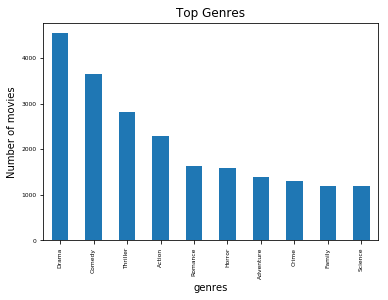

```python
# Initialize the plot
diagram = count[:10].plot.bar(fontsize = 6)
# Set a title
diagram.set(title = 'Top Genres')
# x-label and y-label
diagram.set_xlabel('genres')
diagram.set_ylabel('Number of movies')
# Show the plot
plt.show()
```

most successful genres is Drama

### Movies Released each year

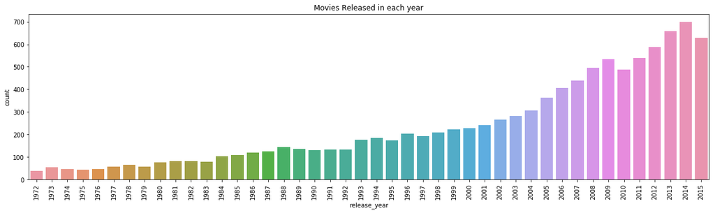

```python
# Use this, and more code cells, to explore your data. Don't forget to add
#   Markdown cells to document your observations and findings.
plt.figure(figsize=(20,5))
sns.countplot(movies_df['release_year'])
plt.xticks(rotation=90)
plt.title('Movies Released in each year')
plt.show()
```

### Movies Released each month

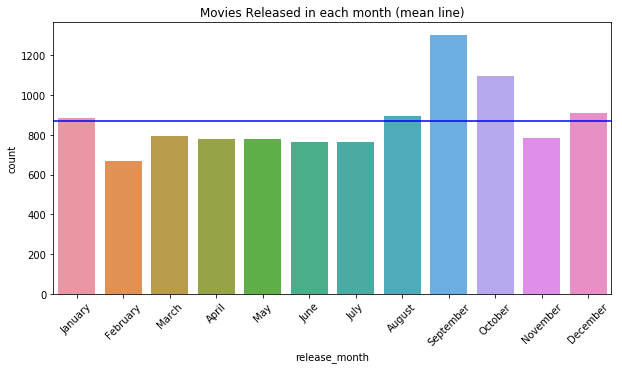

```python
# mean per month
month_mean = movies_df['release_month'].value_counts().values.mean()

month = ['January', 'February', 'March', 'April', 'May',
       'June','July', 'August', 'September','October','November','December']

plt.figure(figsize=(10,5))
sns.countplot(movies_df['release_month'],order=month)
plt.axhline(y = month_mean, color = 'b')
plt.title('Movies Released in each month (mean line)')
plt.xticks(rotation=45)
plt.show()
```

Most movie release are done between August and January

### Popular Movies

```python
# top 10 most popular movies
movies_df.sort_values(by='popularity',ascending=False).head(10)[['original_title','popularity','budget','profit']].style.background_gradient(cmap='cool')
```

|  | original_title | popularity | budget | profit |
| --- | --- | --- | --- | --- |
| 0 | Jurassic World | 32.9858 | 150000000 | 1363528810 |
| 1 | Mad Max: Fury Road | 28.4199 | 150000000 | 228436354 |
| 629 | Interstellar | 24.9491 | 165000000 | 456752480 |
| 630 | Guardians of the Galaxy | 14.3112 | 170000000 | 603312399 |
| 2 | Insurgent | 13.1125 | 110000000 | 185238201 |
| 631 | Captain America: The Winter Soldier | 12.971 | 170000000 | 544766572 |
| 1329 | Star Wars | 12.0379 | 11000000 | 764398007 |
| 632 | John Wick | 11.4228 | 20000000 | 58739897 |
| 3 | Star Wars: The Force Awakens | 11.1731 | 200000000 | 1868178225 |
| 633 | The Hunger Games: Mockingjay - Part 1 | 10.739 | 125000000 | 627100229 |

popular movies are associated with high revenue and profit margins

### longest top 10 movies

```python
# longest top 10 movies in minutes
movies_df.sort_values(by='runtime',ascending=False).head(10)[['original_title','runtime','vote_average']].style.background_gradient(cmap='cool')
```

|  | original_title | runtime | vote_average |
| --- | --- | --- | --- |
| 3894 | The Story of Film: An Odyssey | 900 | 9.2 |
| 4041 | Taken | 877 | 6.8 |
| 2722 | Band of Brothers | 705 | 8 |
| 6176 | Shoah | 566 | 8.3 |
| 6181 | North and South, Book I | 561 | 6 |
| 6894 | Planet Earth | 550 | 7.6 |
| 2214 | The Pacific | 540 | 7.8 |
| 3356 | John Adams | 501 | 6.6 |
| 1865 | Life | 500 | 7 |
| 3141 | Generation Kill | 470 | 6.6 |

The vote average of longer movies is higher than the mean of the entire dataset

### What are the top 10 movies in terms of; Budget, Revenue and Profit

```python
for category in ['budget', 'revenue', 'profit']:
    display(movies_df[[f'{category}', 'original_title']].sort_values(f'{category}', ascending=False).head(10))
```

|  | budget | original_title |
| --- | --- | --- |
| 2244 | 425000000 | The Warrior's Way |
| 3375 | 380000000 | Pirates of the Caribbean: On Stranger Tides |
| 7387 | 300000000 | Pirates of the Caribbean: At World's End |
| 14 | 280000000 | Avengers: Age of Ultron |
| 6570 | 270000000 | Superman Returns |
| 4411 | 260000000 | John Carter |
| 1929 | 260000000 | Tangled |
| 7394 | 258000000 | Spider-Man 3 |
| 5508 | 255000000 | The Lone Ranger |
| 5431 | 250000000 | The Hobbit: The Desolation of Smaug |

|  | revenue | original_title |
| --- | --- | --- |
| 1386 | 2781505847 | Avatar |
| 3 | 2068178225 | Star Wars: The Force Awakens |
| 5231 | 1845034188 | Titanic |
| 4361 | 1519557910 | The Avengers |
| 0 | 1513528810 | Jurassic World |
| 4 | 1506249360 | Furious 7 |
| 14 | 1405035767 | Avengers: Age of Ultron |
| 3374 | 1327817822 | Harry Potter and the Deathly Hallows: Part 2 |
| 5422 | 1274219009 | Frozen |
| 5425 | 1215439994 | Iron Man 3 |

|  | profit | original_title |
| --- | --- | --- |
| 1386 | 2544505847 | Avatar |
| 3 | 1868178225 | Star Wars: The Force Awakens |
| 5231 | 1645034188 | Titanic |
| 0 | 1363528810 | Jurassic World |
| 4 | 1316249360 | Furious 7 |
| 4361 | 1299557910 | The Avengers |
| 3374 | 1202817822 | Harry Potter and the Deathly Hallows: Part 2 |
| 14 | 1125035767 | Avengers: Age of Ultron |
| 5422 | 1124219009 | Frozen |
| 8094 | 1084279658 | The Net |

Movies with The highest budget do not necessarily translate to higher revenue or higher profit margins

Movies which had higher revenue resulted in higher profits for most movies

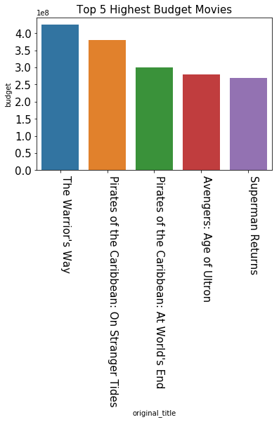

```python
cols = ['original_title', 'budget']
budget_df = movies_df.sort_values('budget', ascending=False)[cols].set_index('original_title')
top_5 = budget_df.head(5)
sns.barplot(data=top_5, x=top_5.index, y='budget');
plt.xticks(ha='left', rotation=-90, fontsize=15);
plt.yticks(fontsize=15)
plt.title('Top 5 Highest Budget Movies', fontsize=15);
```

### Relationship between Budget and Revenue

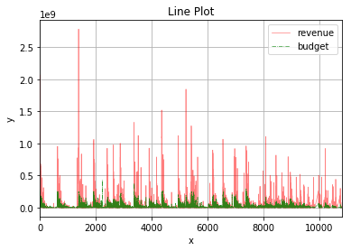

```python
# Line plot
movies_df.revenue.plot(kind='line', color='r', label='revenue', linewidth=.7, alpha=.5, grid=True, linestyle='-' )
movies_df.budget.plot(color='g', label='budget', linewidth=.7, alpha=.8, grid=True, linestyle='-.')
plt.legend(loc='upper right')
plt.xlabel('x')
plt.ylabel('y')
plt.title('Line Plot')
plt.show()
```

[output not shown]

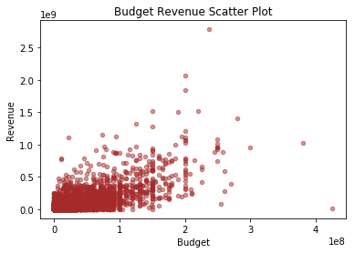

```python
movies_df.plot(kind='scatter', x='budget', y='revenue',alpha = 0.5,color = 'brown')
plt.xlabel('Budget')
plt.ylabel('Revenue')
plt.title('Budget Revenue Scatter Plot')
```

Budget and revenue have a positive correlation. This means an increase in bugdet means an increase in revenue

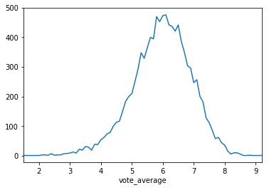

```python
data_groupby_ratings = movies_df.groupby(['vote_average'])['original_title'].count()
data_groupby_ratings.plot()
```

We have more than 400 movies with having a rating around 6.0

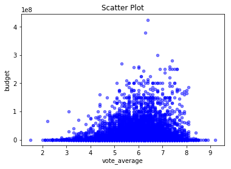

```python
# Scatter Plot
movies_df.plot(kind='scatter', x='vote_average', y='budget', alpha=.5, color='b')
plt.xlabel('vote_average')
plt.ylabel('budget')
plt.title('Scatter Plot')
plt.show()
```

The plot between budget and average vote produces an almost normal distribution. Where Data is highly concentrated towards the mean

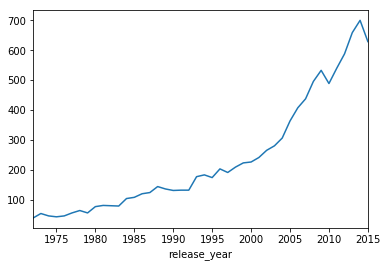

```python
# plot title year vs gross
data_groupby_gross = movies_df.groupby(['release_year'])['revenue'].count()
data_groupby_gross.plot()
```

## Conclusions

> ● Drama was the most popular genre.

> ● Most movie release are done between August and January

> ● popular movies are associated with high revenue and profit margins

> ● Movies with The highest budget do not necessarily translate to higher revenue or higher profit margins

> ● Movies which had higher revenue resulted in higher profits for most movies

```python
from subprocess import call
call(['python', '-m', 'nbconvert', 'Investigate_a_Dataset.ipynb'])
```

```
0
```